# Nishimura Lab Stat Workshop 2021

Elliot Graham

7/8/2021

## Quick Background About Myself

1. Graduate Student pursuing PhD in FSHN
2. Work in the Integrative Cardiovascular Physiology Laboratory (Chris Gentile) as well as the Intestinal Health Laboratory (Tiffany Weir)
3. Huge physiology nerd, with a recent interest in immunometabolism

## Our Study/Question(s) of Interest:

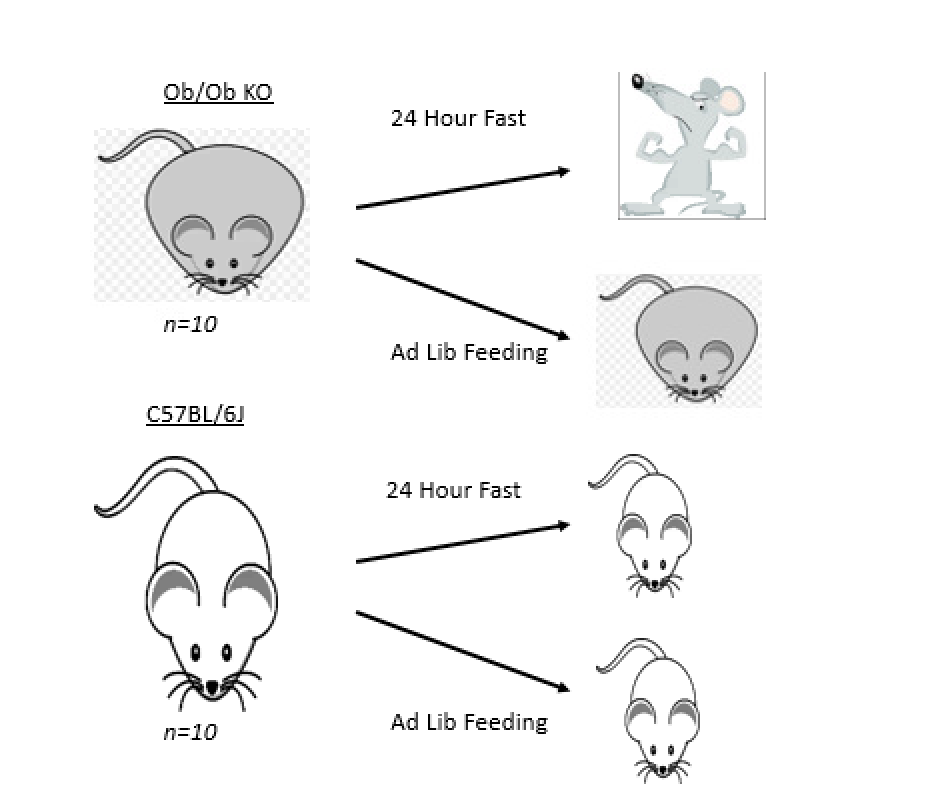

```r
library(readr)
library(RCurl)
library(tidyverse)
library(dplyr)
library(kableExtra)

setwd("/Users/elliotgraham/Desktop/CSU Spring 2021/Gentile Spring 2021/Fasting Study/Flow Stats")

knitr::include_graphics("/Users/elliotgraham/Desktop/CSU Spring 2021/Gentile Spring 2021/Fasting Study/Flow Stats/fastingstudydesign.png",error=FALSE)
```

1: How do does genetic-onset obesity affect immune cell populations/counts in murine liver and adipose tissue (main effect of genotype)?

2: How do does an intermediate duration fasting protocol affect immune cell populations/counts in murine liver and adipose tissue (main effect of intervention)?

3: Is the relationship between how an intermediate duration fasting protocol affects immune cell populations/counts in murine liver and adipose tissue dependent upon genetic-onset obesity (interaction between intervention and genotype)?

4: Since we have both male and female mice, but are underpowered to analyze differences by sex, is sex a confounder?

## Why Poisson/Negative Binomial Regression Models?

1.“A Poisson distribution is a tool that helps to predict the probability of certain events happening when you know how often the event has occurred. It gives us the probability of a given number of events happening in a fixed interval of time.”

so…

Discrete variables are countable in a finite amount of time (i.e. the number of people who walk into a store per day, or the number of cells in a sample).

2. “Negative binomial regression is a generalization of Poisson regression which loosens the restrictive assumption that the variance is equal to the mean made by the Poisson model.”
3. “Negative binomial regression follows the negative binomial distribution. Thus, the possible values of Y are the nonnegative integers: 0, 1, 2, 3, and so on.”

## Upload Data:

```r
library(readr)
library(RCurl)
library(tidyverse)
library(dplyr)
library(kableExtra)

setwd("~/Desktop/CSU Spring 2021/Gentile Spring 2021/Fasting Study/Flow Stats")
counts_liver<- read_csv("~/Desktop/CSU Spring 2021/Gentile Spring 2021/Fasting Study/Flow Stats/counts_liver.csv")
counts_liver$genotype <- factor(counts_liver$genotype  ,levels = c("WT", "Ob"))
counts_liver$intervention <- factor(counts_liver$intervention ,levels = c("Ad-Lib","Fast"))
counts_liver$sex <- factor(counts_liver$sex ,levels = c("M","F"))

str(counts_liver)
```

```
## tibble [35 × 30] (S3: spec_tbl_df/tbl_df/tbl/data.frame)
##  $ id                       : chr [1:35] "M2" "M5" "M6" "M17" ...
##  $ genotype                 : Factor w/ 2 levels "WT","Ob": 1 1 1 1 1 1 1 1 1 1 ...
##  $ intervention             : Factor w/ 2 levels "Ad-Lib","Fast": 1 1 1 1 1 1 1 1 2 2 ...
##  $ sex                      : Factor w/ 2 levels "M","F": 1 1 1 1 2 2 2 2 1 1 ...
##  $ immune_cells             : num [1:35] 261 145 970 215 1365 ...
##  $ b_cells                  : num [1:35] 0.0764 0.0671 0.2271 0.0741 0.4649 ...
##  $ t_cells                  : num [1:35] 205 109 687 127 979 ...
##  $ nkt_cells                : num [1:35] 7.3 4.84 4.09 1.32 7.27 ...
##  $ cyto_t                   : num [1:35] 49.7 34.9 170 34.7 234.7 ...
##  $ eff_cyto_t               : num [1:35] 16.82 7.45 74.34 12.66 81.13 ...
##  $ naïve_cyto_t             : num [1:35] 32.9 27.5 95.6 22 153.6 ...
##  $ double_plus              : num [1:35] 4.84 2.45 14.35 1.52 14.24 ...
##  $ effector_double_plus     : num [1:35] 3.79 1.76 11.17 1.06 10.97 ...
##  $ naïve_double_plus        : num [1:35] 1.051 0.694 3.179 0.463 3.276 ...
##  $ helper_t                 : num [1:35] 58.2 25.7 243.7 37.2 333.1 ...
##  $ effector_helper_t        : num [1:35] 39 16 146.5 19.5 182 ...
##  $ naïve_helepr_t           : num [1:35] 19.16 9.77 97.27 17.7 151.1 ...
##  $ foxp3_cd25_tregs         : num [1:35] 3.35 1.23 10.85 1.32 17.98 ...
##  $ foxp3_tregs              : num [1:35] 52.9 23.7 209.8 16.8 306.6 ...
##  $ cd45_cd11c_mhc2_cdc      : num [1:35] 0.325 0.336 2.407 1.334 3.762 ...
##  $ cd8_plus_cdc             : num [1:35] 0.00955 0.02237 0.13623 0.14827 0.08453 ...
##  $ cd103_cdc                : num [1:35] 0.0287 0.0671 0.3179 0.0185 0.3593 ...
##  $ cd45_cd11b_cd11c_mhc2_cdc: num [1:35] 14.23 7.48 61.31 10.77 70.44 ...
##  $ cd103_cd11b_cdc          : num [1:35] 4.36 1.82 25.11 1.82 30.43 ...
##  $ cd11b_cdc                : num [1:35] 9.87 5.66 36.19 8.95 40 ...
##  $ neutrophils              : num [1:35] 0 0 0 0.0185 0.0211 ...
##  $ ly6c_plus_neutrophils    : num [1:35] 0.0382 0.0671 0.3179 0.1483 0.1479 ...
##  $ monocytes                : num [1:35] 11.67 6.75 67.75 24.28 89.31 ...
##  $ 80_plus_mac              : num [1:35] 0.0287 0.0895 0.9536 0.0741 0.803 ...
##  $ 80_minus_mac             : num [1:35] 2.14 2.08 16.94 8.56 32.52 ...
##  - attr(*, "spec")=
##   .. cols(
##   ..   id = col_character(),
##   ..   genotype = col_character(),
##   ..   intervention = col_character(),
##   ..   sex = col_character(),
##   ..   immune_cells = col_double(),
##   ..   b_cells = col_double(),
##   ..   t_cells = col_double(),
```

[output cut: 9 more lines]

```
##   ..   naïve_helepr_t = col_double(),
##   ..   foxp3_cd25_tregs = col_double(),
##   ..   foxp3_tregs = col_double(),
##   ..   cd45_cd11c_mhc2_cdc = col_double(),
##   ..   cd8_plus_cdc = col_double(),
##   ..   cd103_cdc = col_double(),
##   ..   cd45_cd11b_cd11c_mhc2_cdc = col_double(),
##   ..   cd103_cd11b_cdc = col_double(),
##   ..   cd11b_cdc = col_double(),
##   ..   neutrophils = col_double(),
##   ..   ly6c_plus_neutrophils = col_double(),
##   ..   monocytes = col_double(),
##   ..   `80_plus_mac` = col_double(),
##   ..   `80_minus_mac` = col_double()
##   .. )
```

## Boxplot and Descriptive Statistics

```r
library(readr)
library(RCurl)
library(tidyverse)
library(dplyr)
library(kableExtra)
library(ggplot2)

counts_liver_cells_stats<-counts_liver%>%group_by(genotype,intervention)%>%summarise(n=n(),mean=mean(cyto_t,na.rm=TRUE),median=median(cyto_t,na.rm=TRUE),sd=sd(cyto_t,na.rm=TRUE),min=min(cyto_t,na.rm=TRUE),max=max(cyto_t,na.rm=TRUE))

knitr::kable(counts_liver_cells_stats,digits=2)%>%kable_styling(full_width = F)
```

| genotype | intervention | n | mean | median | sd | min | max |
| --- | --- | --- | --- | --- | --- | --- | --- |
| WT | Ad-Lib | 8 | 112.11 | 48.99 | 100.23 | 34.68 | 278.45 |
| WT | Fast | 10 | 21.89 | 22.59 | 11.79 | 2.27 | 41.73 |
| Ob | Ad-Lib | 8 | 4.38 | 2.95 | 3.78 | 0.70 | 12.23 |
| Ob | Fast | 9 | 21.37 | 10.96 | 25.83 | 1.54 | 65.11 |

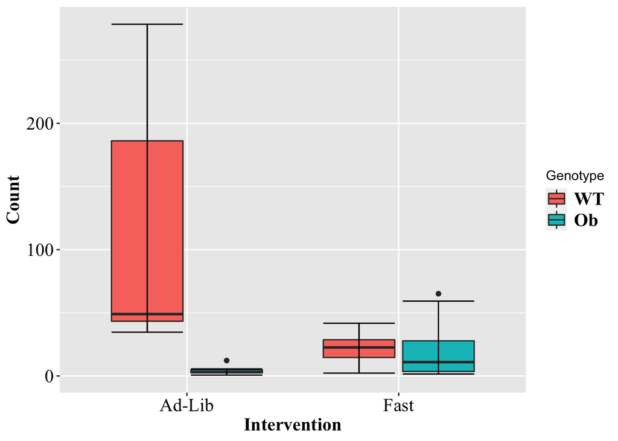

```r
boxplot_cyto_t<-ggplot(counts_liver,aes(intervention,cyto_t,fill=genotype)) +
  geom_boxplot() +
  ylab("Count")+
  xlab("Intervention")+theme(axis.text.x = element_text(family="Times New Roman", size=15,color="black"))+theme(axis.title.x= element_text(family="Times New Roman", size=15,face="bold",color="black"))+theme(axis.text.y = element_text(family="Times New Roman", size=15,color="black"))+theme(axis.title.y= element_text(family="Times New Roman", size=15,face="bold",color="black"))+theme(legend.text= element_text(family="Times New Roman", size=15,face="bold",color="black"))+ labs(fill = "Genotype")+ stat_boxplot(geom ='errorbar')

boxplot_cyto_t
```

## Poisson Regression with robust standard errors (for mild violations of the distribution assumption that the variance equals the mean)

```r
library(sandwich)
library(car)
library(emmeans)

cyto_t_poisson <- glm(cyto_t ~ genotype*intervention+sex, family="poisson", data=counts_liver)

summary(cyto_t_poisson)
```

```
##
## Call:
## glm(formula = cyto_t ~ genotype * intervention + sex, family = "poisson",
##     data = counts_liver)
##
## Deviance Residuals:
##     Min       1Q   Median       3Q      Max
## -9.0946  -3.9076  -0.5456   1.8407  10.4857
##
## Coefficients:
##                             Estimate Std. Error z value Pr(>|z|)
## (Intercept)                  4.45634    0.04828   92.30   <2e-16 ***
## genotypeOb                  -3.13863    0.18416  -17.04   <2e-16 ***
## interventionFast            -1.63364    0.07539  -21.67   <2e-16 ***
## sexF                         0.47122    0.05664    8.32   <2e-16 ***
## genotypeOb:interventionFast  3.11469    0.21055   14.79   <2e-16 ***
## ---
## Signif. codes:  0 '***' 0.001 '**' 0.01 '*' 0.05 '.' 0.1 ' ' 1
##
## (Dispersion parameter for poisson family taken to be 1)
##
##     Null deviance: 2110.64  on 32  degrees of freedom
## Residual deviance:  799.54  on 28  degrees of freedom
##   (2 observations deleted due to missingness)
## AIC: Inf
##
## Number of Fisher Scoring iterations: 5
```

```r
cov.cyto_t_poisson <- vcovHC(cyto_t_poisson, type="HC0")
std.err <- sqrt(diag(cov.cyto_t_poisson))
r.est <- cbind(Estimate= coef(cyto_t_poisson), "Robust SE" = std.err,
"Pr(>|z|)" = 2 * pnorm(abs(coef(cyto_t_poisson)/std.err), lower.tail=FALSE),
LL = coef(cyto_t_poisson) - 1.96 * std.err,
UL = coef(cyto_t_poisson) + 1.96 * std.err)

r.est
```

```
##                              Estimate Robust SE     Pr(>|z|)         LL
## (Intercept)                  4.456341 0.2939831 6.657667e-52  3.8801343
## genotypeOb                  -3.138631 0.4346913 5.184730e-13 -3.9906260
## interventionFast            -1.633644 0.3236575 4.477528e-07 -2.2680125
## sexF                         0.471218 0.3739846 2.076718e-01 -0.2617917
## genotypeOb:interventionFast  3.114690 0.6299948 7.653851e-07  1.8799000
##                                     UL
## (Intercept)                  5.0325479
## genotypeOb                  -2.2866360
## interventionFast            -0.9992753
## sexF                         1.2042277
## genotypeOb:interventionFast  4.3494796
```

## Negative binomial vs Poisson:

```r
library(foreign)
library(MASS)
library(AER)
library(performance)

cyto_t_neg_bin <- glm.nb(cyto_t ~ genotype*intervention+sex, data = counts_liver)

summary(cyto_t_neg_bin)
```

```
##
## Call:
## glm.nb(formula = cyto_t ~ genotype * intervention + sex, data = counts_liver,
##     init.theta = 1.524925553, link = log)
##
## Deviance Residuals:
##     Min       1Q   Median       3Q      Max
## -2.0550  -0.9263  -0.4234   0.3282   1.7018
##
## Coefficients:
##                             Estimate Std. Error z value Pr(>|z|)
## (Intercept)                   4.6744     0.3252  14.375  < 2e-16 ***
## genotypeOb                   -3.2088     0.4617  -6.950 3.66e-12 ***
## interventionFast             -1.6220     0.3915  -4.143 3.42e-05 ***
## sexF                          0.0675     0.3008   0.224    0.822
## genotypeOb:interventionFast   3.1860     0.6092   5.230 1.70e-07 ***
## ---
## Signif. codes:  0 '***' 0.001 '**' 0.01 '*' 0.05 '.' 0.1 ' ' 1
##
## (Dispersion parameter for Negative Binomial(1.5249) family taken to be 1)
##
##     Null deviance: 87.891  on 32  degrees of freedom
## Residual deviance: 35.777  on 28  degrees of freedom
##   (2 observations deleted due to missingness)
## AIC: 284.64
##
## Number of Fisher Scoring iterations: 1
##
##
##               Theta:  1.525
##           Std. Err.:  0.386
##
##  2 x log-likelihood:  -272.641
```

```r
check_overdispersion(cyto_t_poisson)
```

```
## # Overdispersion test
##
##        dispersion ratio =  29.610
##   Pearson's Chi-Squared = 829.080
##                 p-value = < 0.001
```

## So, what do we see?

1. Overdispersion Test
2. Fisher Score iterations:
   - “This is the number of iterations to fit the model. The model uses an iterative maximum likelihood algorithm to fit the data. The Fisher method is the same as fitting a model by iteratively re-weighting the least squares. It indicates the optimal number of iterations. For example, beyond some number of iterations there are no practical gains”
3. AIC:
   - “The Akaike information criterion (AIC) is an estimator of out-of-sample prediction error and thereby relative quality of statistical models for a given set of data. AIC uses a model’s maximum likelihood estimation (log-likelihood) as a measure of fit. Log-likelihood is a measure of how likely one is to see their observed data, given a model. The model with the maximum likelihood is the one that “fits” the data the best."
4. Coefficients

## Post Hoc Comparisons

```r
immune_cells.emm <- emmeans(cyto_t_neg_bin,~intervention*genotype)
pairs(immune_cells.emm,adjust="tukey",type="response")
```

```
##  contrast                   ratio      SE  df z.ratio p.value
##  (Ad-Lib WT) / Fast WT      5.063  1.9821 Inf  4.143  0.0002
##  (Ad-Lib WT) / (Ad-Lib Ob) 24.748 11.4267 Inf  6.950  <.0001
##  (Ad-Lib WT) / Fast Ob      5.180  2.1415 Inf  3.978  0.0004
##  Fast WT / (Ad-Lib Ob)      4.888  2.1873 Inf  3.546  0.0022
##  Fast WT / Fast Ob          1.023  0.4066 Inf  0.057  0.9999
##  (Ad-Lib Ob) / Fast Ob      0.209  0.0977 Inf -3.350  0.0045
##
## Results are averaged over the levels of: sex
## P value adjustment: tukey method for comparing a family of 4 estimates
## Tests are performed on the log scale
```

-“Tukey’s honestly significant difference test uses the Studentized range statistic to make all pairwise comparisons between groups and sets the experimentwise error rate to the error rate for the collection for all pairwise comparisons.”

-“The z value follows a standard normal distribution which is used to test against a two-sided alternative hypothesis that the Coef. is not equal to zero.”

-So,the usual post-hoc tests like Bonferroni and Tukey should apply.

## Graph of Liver Cytotoxic T Cells

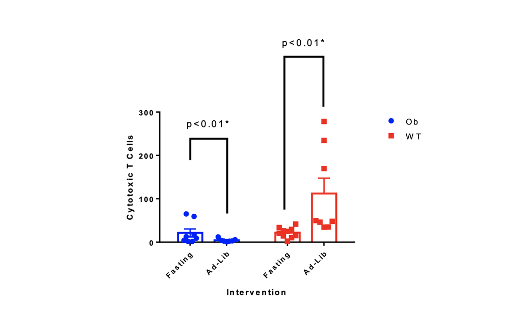

```r
library(readr)
library(RCurl)
library(tidyverse)
library(dplyr)
library(kableExtra)

setwd("/Users/elliotgraham/Desktop/CSU Spring 2021/Gentile Spring 2021/Fasting Study/Flow Stats")

knitr::include_graphics("/Users/elliotgraham/Desktop/CSU Spring 2021/Gentile Spring 2021/Fasting Study/Flow Stats/Liver Cytotoxic T Cells.png",error=FALSE)
```

-Intermediate duration fasting reversed liver Cytotoxic T cell deficiencies in Ob mice, yet reduced liver Cytotoxic T cell counts in WT mice.

## Upload Data:

```
## tibble [37 × 30] (S3: tbl_df/tbl/data.frame)
##  $ id                       : chr [1:37] "M5" "M6" "M14" "M17" ...
##  $ genotype                 : Factor w/ 2 levels "WT","Ob": 1 1 1 1 1 1 1 1 1 1 ...
##  $ intervention             : Factor w/ 2 levels "Ad-Lib","Fast": 1 1 1 1 1 1 1 1 2 2 ...
##  $ sex                      : Factor w/ 2 levels "M","F": 1 1 1 1 2 2 2 2 1 1 ...
##  $ immune_cells             : num [1:37] 60.8 NA 1354.5 369.2 447 ...
##  $ b_cells                  : num [1:37] 0.0209 1.3504 5.1307 0.2136 0.7998 ...
##  $ t_cells                  : num [1:37] 49.4 7148.3 1015.9 97.2 196.1 ...
##  $ nkt_cells                : num [1:37] 7.29 NA 158.5 12.88 15.94 ...
##  $ cyto_t                   : num [1:37] 8.92 NA 758.68 15.62 52.47 ...
##  $ eff_cyto_t               : num [1:37] 0.321 30.309 9.069 0.275 0.267 ...
##  $ naïve_cyto_t             : num [1:37] 8.6 NA 749.6 15.3 52.2 ...
##  $ double_plus              : num [1:37] 1.633 38.562 62.012 0.946 7.225 ...
##  $ effector_double_plus     : num [1:37] 0.14 4.501 NA 0.107 0.533 ...
##  $ naïve_double_plus        : num [1:37] 1.493 34.06 45.15 0.839 6.692 ...
```

[output cut: 16 more lines]

## Boxplot and Descriptive Statistics

| genotype | intervention | n | mean | median | sd | min | max |
| --- | --- | --- | --- | --- | --- | --- | --- |
| WT | Ad-Lib | 8 | 248.10 | 52.47 | 341.90 | 8.92 | 758.68 |
| WT | Fast | 9 | 2013.03 | 245.59 | 2357.75 | 33.88 | 5741.54 |
| Ob | Ad-Lib | 10 | 35.12 | 19.92 | 35.12 | 2.58 | 110.31 |
| Ob | Fast | 10 | 24.62 | 14.74 | 25.81 | 6.51 | 83.24 |

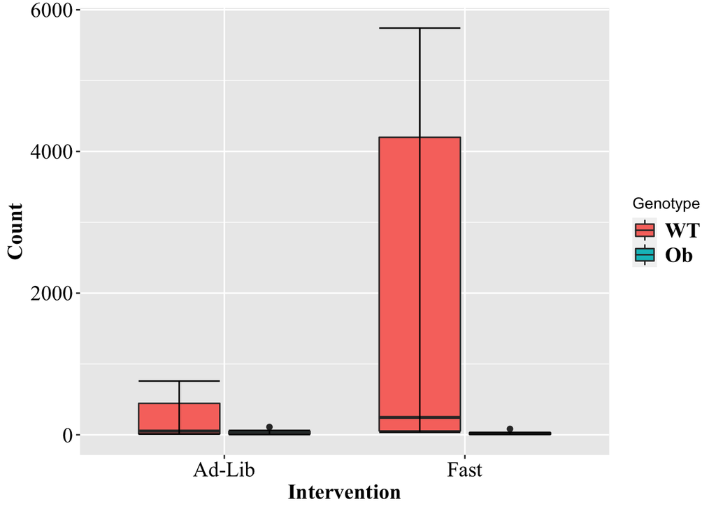

## Poisson Regression with robust standard errors (for mild violations of the distribution assumption that the variance equals the mean)

```
##
## Call:
## glm(formula = cyto_t ~ genotype * intervention + sex, family = "poisson",
##     data = counts_mat)
##
## Deviance Residuals:
##     Min       1Q   Median       3Q      Max
## -68.677  -11.223   -2.474    6.607   69.315
##
## Coefficients:
##                             Estimate Std. Error z value Pr(>|z|)
## (Intercept)                  5.82505    0.02481  234.77   <2e-16 ***
## genotypeOb                  -2.03294    0.06117  -33.23   <2e-16 ***
## interventionFast             2.01555    0.02518   80.04   <2e-16 ***
## sexF                        -0.63116    0.01520  -41.52   <2e-16 ***
## genotypeOb:interventionFast -2.33741    0.09422  -24.81   <2e-16 ***
## ---
## Signif. codes:  0 '***' 0.001 '**' 0.01 '*' 0.05 '.' 0.1 ' ' 1
##
## (Dispersion parameter for poisson family taken to be 1)
##
##     Null deviance: 65054  on 32  degrees of freedom
## Residual deviance: 26622  on 28  degrees of freedom
##   (4 observations deleted due to missingness)
## AIC: Inf
##
## Number of Fisher Scoring iterations: 6
```

```
##                               Estimate Robust SE     Pr(>|z|)         LL
## (Intercept)                  5.8250514 0.5733943 3.024894e-24  4.7011986
## genotypeOb                  -2.0329402 0.5860578 5.227129e-04 -3.1816136
## interventionFast             2.0155531 0.6169591 1.087262e-03  0.8063133
## sexF                        -0.6311581 0.7243137 3.835424e-01 -2.0508129
## genotypeOb:interventionFast -2.3374068 0.8018248 3.555643e-03 -3.9089834
##                                     UL
## (Intercept)                  6.9489042
## genotypeOb                  -0.8842668
## interventionFast             3.2247929
## sexF                         0.7884967
## genotypeOb:interventionFast -0.7658301
```

## Negative binomial vs Poisson:

```
##
## Call:
## glm.nb(formula = cyto_t ~ genotype * intervention + sex, data = counts_mat,
##     init.theta = 0.6670312865, link = log)
##
## Deviance Residuals:
##     Min       1Q   Median       3Q      Max
## -2.0390  -1.3068  -0.4535   0.3369   1.2968
##
## Coefficients:
##                             Estimate Std. Error z value Pr(>|z|)
## (Intercept)                   5.6044     0.5248  10.678  < 2e-16 ***
## genotypeOb                   -1.9877     0.6225  -3.193 0.001409 **
## interventionFast              2.0505     0.6200   3.307 0.000942 ***
## sexF                         -0.1592     0.4313  -0.369 0.712033
## genotypeOb:interventionFast  -2.3543     0.8658  -2.719 0.006545 **
## ---
## Signif. codes:  0 '***' 0.001 '**' 0.01 '*' 0.05 '.' 0.1 ' ' 1
##
## (Dispersion parameter for Negative Binomial(0.667) family taken to be 1)
##
##     Null deviance: 102.50  on 32  degrees of freedom
## Residual deviance:  39.51  on 28  degrees of freedom
##   (4 observations deleted due to missingness)
## AIC: 403.78
##
## Number of Fisher Scoring iterations: 1
##
##
##               Theta:  0.667
##           Std. Err.:  0.141
##
##  2 x log-likelihood:  -391.781
```

```
## # Overdispersion test
##
##        dispersion ratio =   884.267
##   Pearson's Chi-Squared = 24759.466
##                 p-value =   < 0.001
```

## Post Hoc Comparisons

```
##  contrast                   ratio      SE  df z.ratio p.value
##  (Ad-Lib WT) / Fast WT      0.129  0.0798 Inf -3.307  0.0052
##  (Ad-Lib WT) / (Ad-Lib Ob)  7.299  4.5438 Inf  3.193  0.0077
##  (Ad-Lib WT) / Fast Ob      9.890  6.3179 Inf  3.587  0.0019
##  Fast WT / (Ad-Lib Ob)     56.722 32.9000 Inf  6.962  <.0001
##  Fast WT / Fast Ob         76.864 46.0882 Inf  7.241  <.0001
##  (Ad-Lib Ob) / Fast Ob      1.355  0.8161 Inf  0.505  0.9580
##
## Results are averaged over the levels of: sex
## P value adjustment: tukey method for comparing a family of 4 estimates
## Tests are performed on the log scale
```

## Graph of MAT Cytotoxic T Cells

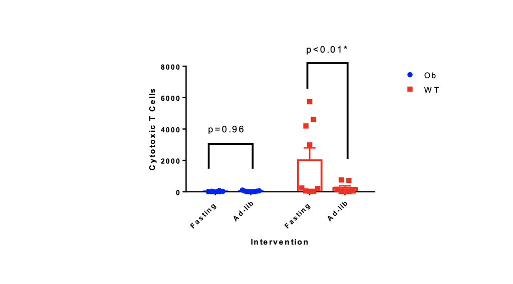

```r
library(readr)
library(RCurl)
library(tidyverse)
library(dplyr)
library(kableExtra)

setwd("/Users/elliotgraham/Desktop/CSU Spring 2021/Gentile Spring 2021/Fasting Study/Flow Stats")

knitr::include_graphics("/Users/elliotgraham/Desktop/CSU Spring 2021/Gentile Spring 2021/Fasting Study/Flow Stats/MAT Cytotoxic T Cells.png",error=FALSE)
```

## Graph of Cytotoxic T Cells

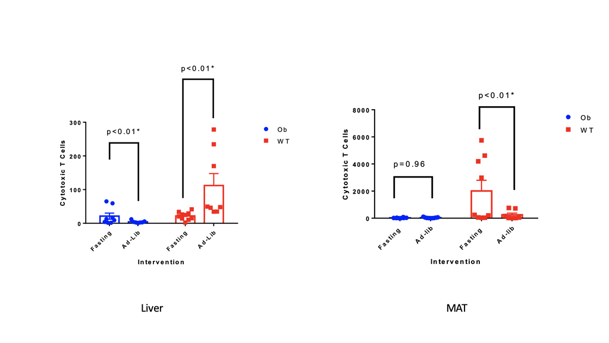

```r
library(readr)
library(RCurl)
library(tidyverse)
library(dplyr)
library(kableExtra)

setwd("/Users/elliotgraham/Desktop/CSU Spring 2021/Gentile Spring 2021/Fasting Study/Flow Stats")

knitr::include_graphics("/Users/elliotgraham/Desktop/CSU Spring 2021/Gentile Spring 2021/Fasting Study/Flow Stats/Cytotoxic T Cells.png",error=FALSE)
```

Therefore, the ability of intermediate duration fasting to modulate Ob and WT mice immune cell populations might be tissue specific/dependent!

## References:

1. https://www.statisticshowto.com/poisson-distribution/
2. https://ncss-wpengine.netdna-ssl.com/wp-content/themes/ncss/pdf/Procedures/NCSS/Negative_Binomial_Regression.pdf
3. https://webfocusinfocenter.informationbuilders.com/wfappent/TLs/TL_rstat/source/LogisticRegression43.htm
4. https://towardsdatascience.com/introduction-to-aic-akaike-information-criterion-9c9ba1c96ced
5. https://www.ibm.com/docs/ko/spss-statistics/23.0.0?topic=analysis-glm-post-hoc-comparisons
6. https://stats.idre.ucla.edu/stata/output/negative-binomial-regression/